# Engagement vs. Performance on the MedU Platform

Progress Report 2016-03-21

Charlie Guthrie

March 21, 2016

## Project Overview

I’m building a model to predict a student’s performance in an online course from his/her level of engagement in the class. The ultimate goal is to determine which engagement activities contribute most to student performance and understanding. I’m using a data set from NYU Langone from MedU, an online learning platform for medical courses.

## About the Data

Student performance is measured by score on multiple-choice questions throughout the 23-card unit.  
See a screenshot of a sample card below.

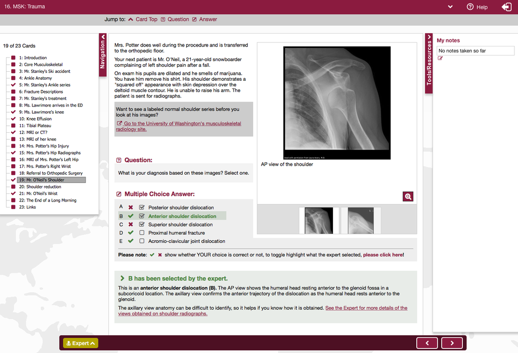

Variables that may have an impact on student performance:

- Clicking hyperlinks
- Enlarging images
- Checking answers
- Time spent on cards

```r
library(knitr)
source('../scripts/explore_data.R')
df = load_data()

source('../scripts/processing.R')
outdf = restructure(df)
outdf = rename_cols(outdf,new_names)
data = train_test_split(outdf)
train=data[[1]]
test=data[[2]]
kable(head(outdf))
```

| user_id | label | success | hyperlink_clicks | magnify_clicks | expert_clicks | handling_time | card_num |
| --- | --- | --- | --- | --- | --- | --- | --- |
| 150301 | 0 | 0 | 1 | 0 | 0 | 40 | 5 |
| 175964 | 1 | 66 | 0 | 0 | 0 | 294 | 5 |
| 192763 | 1 | 66 | 0 | 1 | 0 | 1198 | 5 |
| 203883 | 0 | 33 | 0 | 1 | 0 | 178 | 5 |
| 210022 | 0 | 33 | 0 | 0 | 0 | 146 | 5 |
| 212749 | 1 | 100 | 0 | 1 | 0 | 253 | 5 |

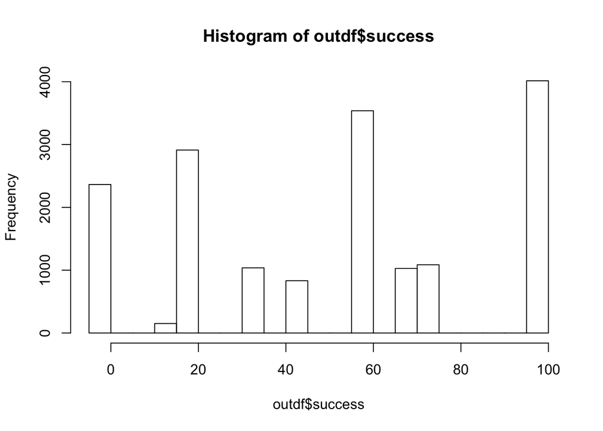

```r
hist(outdf$success)
```

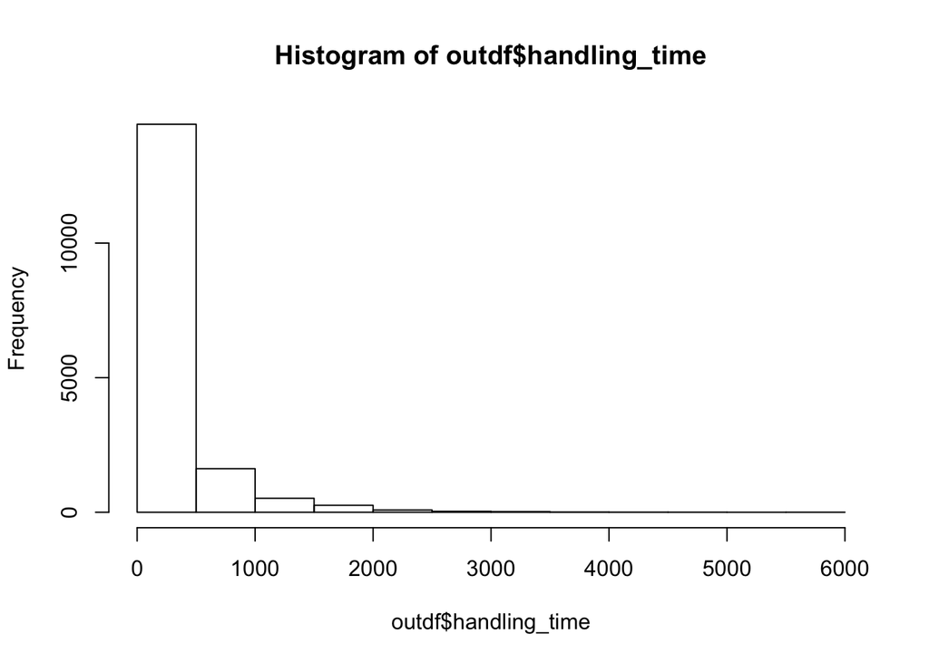

```r
hist(outdf$handling_time)
```

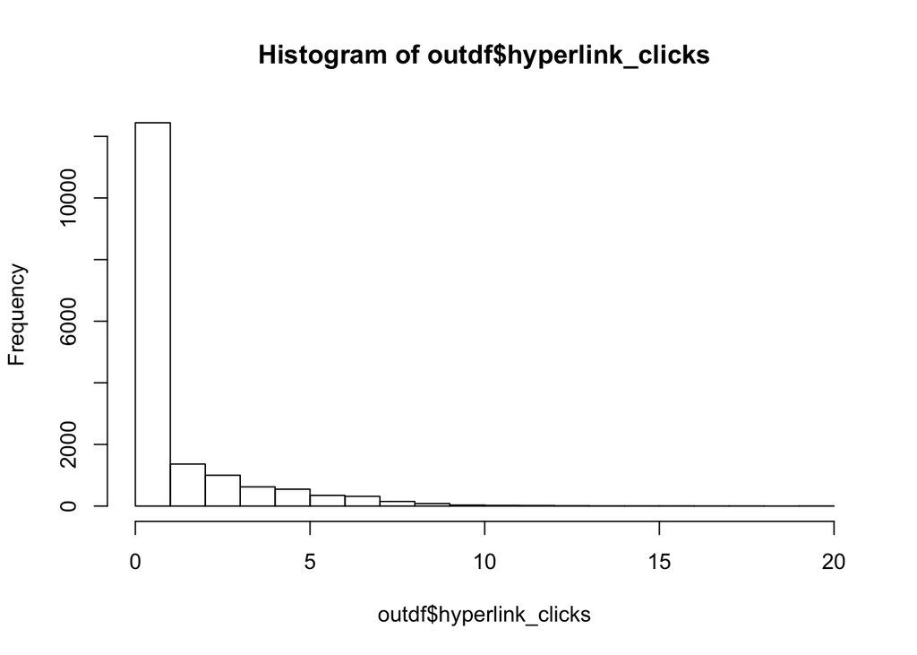

```r
hist(outdf$hyperlink_clicks)
```

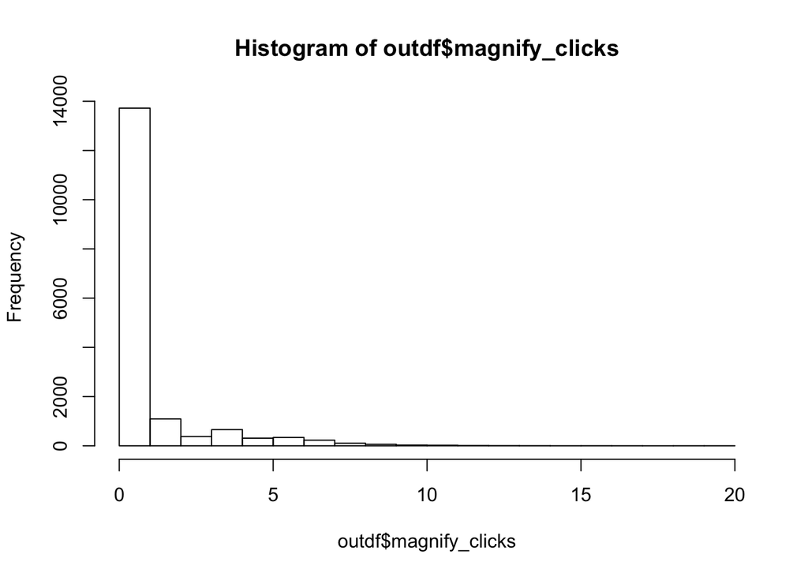

```r
hist(outdf$magnify_clicks)
```

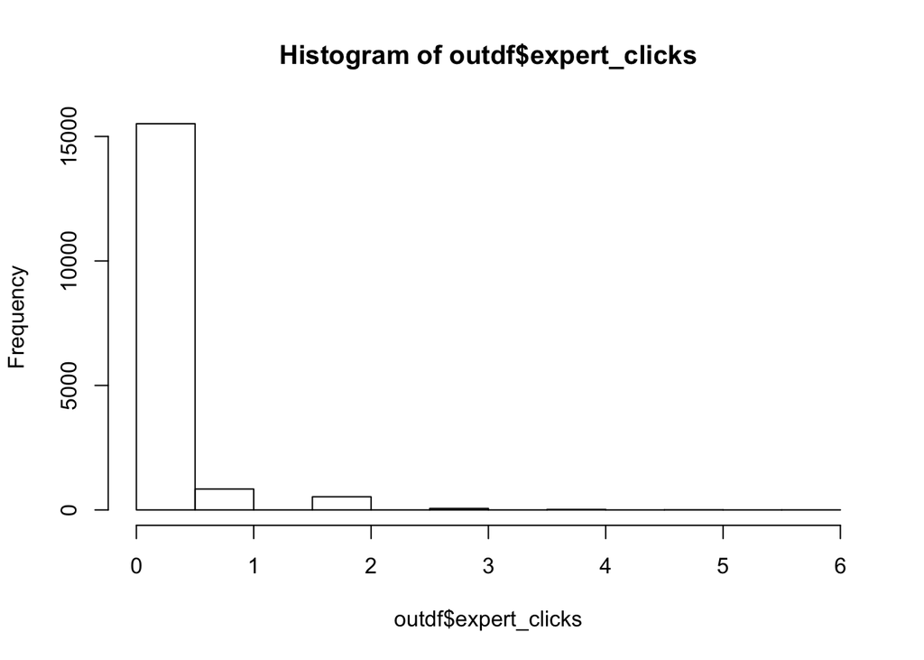

```r
hist(outdf$expert_clicks)
```

## First Models

```r
source('../scripts/models.R')
```

### Logistic

```r
mylogit <- glm(label ~ hyperlink_clicks + magnify_clicks + expert_clicks + handling_time, data = train, family = "binomial")
summary(mylogit)
```

```
##
## Call:
## glm(formula = label ~ hyperlink_clicks + magnify_clicks + expert_clicks +
##     handling_time, family = "binomial", data = train)
##
## Deviance Residuals:
##     Min       1Q   Median       3Q      Max
## -2.1178  -1.2330   0.9234   1.0975   1.1369
##
## Coefficients:
##                   Estimate Std. Error z value Pr(>|z|)
## (Intercept)      9.614e-02  2.390e-02   4.023 5.74e-05 ***
## hyperlink_clicks 5.770e-02  9.976e-03   5.784 7.31e-09 ***
## magnify_clicks   7.421e-02  1.178e-02   6.301 2.95e-10 ***
## expert_clicks    4.636e-02  4.552e-02   1.018    0.308
## handling_time    1.999e-04  4.925e-05   4.058 4.94e-05 ***
## ---
## Signif. codes:  0 '***' 0.001 '**' 0.01 '*' 0.05 '.' 0.1 ' ' 1
##
## (Dispersion parameter for binomial family taken to be 1)
##
##     Null deviance: 17355  on 12708  degrees of freedom
## Residual deviance: 17176  on 12704  degrees of freedom
## AIC: 17186
##
## Number of Fisher Scoring iterations: 4
```

However, the model still needs a lot of work. It does not appear very accurate.

Train Accuracy:

```
##          actual
## predicted    0    1
##         0 4836 6053
##         1  606 1214
```

```
## [1] "accuracy:"         "0.476040601148792"
```

Test Accuracy:

```
##          actual
## predicted    0    1
##         0 1643 1975
##         1  211  424
```

```
## [1] "accuracy:"         "0.486009875382083"
```

### Decision Tree

Next I tried a decision tree, borrowing code from the classification tutorial:

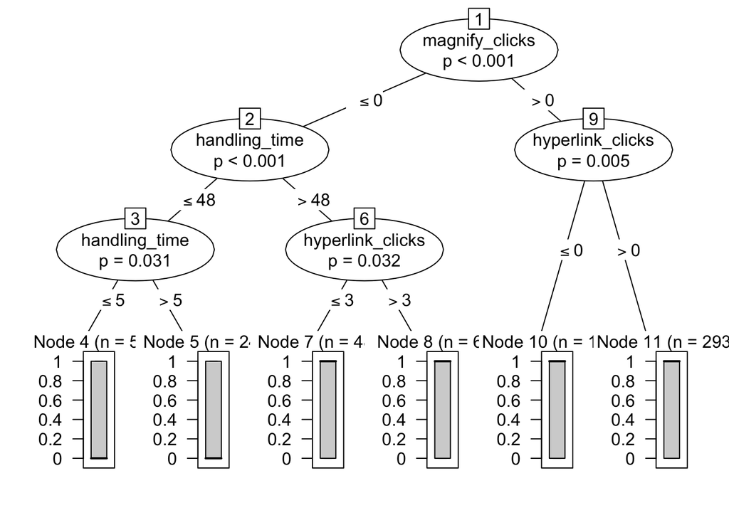

```r
mydat_tree <- ctree(label ~ hyperlink_clicks + magnify_clicks + expert_clicks + handling_time, data = train)
plot(mydat_tree)
```

Train Accuracy:

```
##          actual
## predicted    0    1
##         0 1687 1330
##         1 3755 5937
```

```
## [1] "accuracy:"         "0.599889841844362"
```

Test Accuracy:

```
##          actual
## predicted    0    1
##         0  575  425
##         1 1279 1974
```

```
## [1] "accuracy:"         "0.599341641194451"
```

## Next Steps

There is still a lot of work to do. I will tweak the logistic classifier, trying out different variables and variations on the existing variables.

The tree classifier shows more promise.

I also want to visualize the results better